# Overlaps of DA regions

15 April 2019

We have performed differential accessibility (DA) analysis on the ATAC-seq data, testing for differences between the somite trios and between the different stages. To effectively remove technical biases, we computed the residuals from the fit of the `somite*stage` interaction, and performed PCA on them; we used the first 18 PCs as covariates in the DA analysis (18 PCs were chosen based on parallel analysis, which uses permutations of the count data to calculate the amount of variance explained under a null model; only PCs that explain more variance than under the null are retained). The number of significant regions are summarised below:

```r
## metadata
meta <- read.table(paste0(dir, "ATAC-seq/data/metadata_ATACseq_GQ.tsv"), stringsAsFactors = FALSE, header = TRUE)
meta <- meta[meta$QCpass==1,]

### DA regions
### merge the results from all different comparisons into a single table, keeping the FDR and maximum fold-change for each comparison for each region

## somite trios
# per stage
trios.perStage <- readRDS(paste0(dir, "ATAC-seq/results/04.3_diffAccessibility_somiteTrios_perStage_pca.Rds"))
for(i in 1:length(trios.perStage)){
  trios.perStage[[i]] <- trios.perStage[[i]][order(trios.perStage[[i]])]
  trios.perStage[[i]]$maxFC <- apply(mcols(trios.perStage[[i]])[,11:13], 1, function(x) x[which.max(abs(x))])
}
stopifnot(identical(ranges(trios.perStage[["stage8"]]), ranges(trios.perStage[["stage18"]])))
stopifnot(identical(ranges(trios.perStage[["stage21"]]), ranges(trios.perStage[["stage35"]])))

trios.perStage.all <- as.data.frame(trios.perStage[["stage8"]])[,c(1:4,6,14,20)]
colnames(trios.perStage.all)[(ncol(trios.perStage.all)-1):ncol(trios.perStage.all)] <- paste0("stage8", c(".FDR", ".FC"))
trios.perStage.all$stage18.FDR <- trios.perStage[["stage18"]]$FDR
trios.perStage.all$stage18.FC <- trios.perStage[["stage18"]]$maxFC
trios.perStage.all$stage21.FDR <- trios.perStage[["stage21"]]$FDR
trios.perStage.all$stage21.FC <- trios.perStage[["stage21"]]$maxFC
trios.perStage.all$stage25.FDR <- trios.perStage[["stage25"]]$FDR
trios.perStage.all$stage25.FC <- trios.perStage[["stage25"]]$maxFC
trios.perStage.all$stage35.FDR <- trios.perStage[["stage35"]]$FDR
trios.perStage.all$stage35.FC <- trios.perStage[["stage35"]]$maxFC

## only regions with an FDR < 0.05 and an absolute fold-change larger than 1.5 for at least one comparison are kept
fdr <- ifelse(rowSums(trios.perStage.all[,seq(6,14,2)] < 0.05)>0, 1, 0)
fc <- ifelse(rowSums(abs(trios.perStage.all[,seq(7,15,2)]) > log2(1.5))>0, 1, 0)
trios.perStage.all <- trios.perStage.all[fdr & fc,]
row.names(trios.perStage.all) <- paste0(trios.perStage.all$seqnames, ":", trios.perStage.all$start, "-", trios.perStage.all$end)

nDE <- t(data.frame(stage8 = nrow(trios.perStage.all[trios.perStage.all$stage8.FDR < 0.05,]),
                  stage18 = nrow(trios.perStage.all[trios.perStage.all$stage18.FDR < 0.05,]),
                  stage21 = nrow(trios.perStage.all[trios.perStage.all$stage21.FDR < 0.05,]),
                  stage25 = nrow(trios.perStage.all[trios.perStage.all$stage25.FDR < 0.05,]),
                  stage35 = nrow(trios.perStage.all[trios.perStage.all$stage35.FDR < 0.05,])))
colnames(nDE) <- "trios.perStage"
nDE
```

```
##         trios.perStage
## stage8             563
## stage18            161
## stage21              6
## stage25           1030
## stage35             38
```

```r
# stage average
trios.average <- readRDS(paste0(dir, "ATAC-seq/results/04.3_diffAccessibility_somiteTrios_average_pca.Rds"))
for(i in 1:length(trios.average)){
  trios.average[[i]] <- trios.average[[i]][order(trios.average[[i]])]
}
stopifnot(identical(ranges(trios.average[["somiteIIvsI"]]), ranges(trios.average[["somiteIIIvsI"]])))
stopifnot(identical(ranges(trios.average[["somiteIIIvsI"]]), ranges(trios.average[["somiteIIIvsII"]])))

trios.average.all <- as.data.frame(trios.average[["somiteIIvsI"]])[,c(1:4,6,10,13)]
colnames(trios.average.all)[(ncol(trios.average.all)-1):ncol(trios.average.all)] <- paste0("somiteIIvsI", c(".FDR", ".FC"))
trios.average.all$somiteIIIvsII.FDR <- trios.average[["somiteIIIvsII"]]$FDR
trios.average.all$somiteIIIvsII.FC <- trios.average[["somiteIIIvsII"]]$logFC
trios.average.all$somiteIIIvsI.FDR <- trios.average[["somiteIIIvsI"]]$FDR
trios.average.all$somiteIIIvsI.FC <- trios.average[["somiteIIIvsI"]]$logFC

fdr <- ifelse(rowSums(trios.average.all[,c(6,8,10)] < 0.05)>0, 1, 0)
fc <- ifelse(rowSums(abs(trios.average.all[,c(7,9,11)]) > log2(1.5))>0, 1, 0)

trios.average.all <- trios.average.all[fdr & fc,]
row.names(trios.average.all) <- paste0(trios.average.all$seqnames, ":", trios.average.all$start, "-", trios.average.all$end)

nDE <- t(data.frame(somiteIvsII = nrow(trios.average.all[trios.average.all$somiteIIvsI.FDR < 0.05,]),
                  somiteIIvsIII = nrow(trios.average.all[trios.average.all$somiteIIIvsII.FDR < 0.05,]),
                  somiteIvsIII = nrow(trios.average.all[trios.average.all$somiteIIIvsI.FDR < 0.05,])))
colnames(nDE) <- "trios.average"
nDE
```

```
##               trios.average
## somiteIvsII              75
## somiteIIvsIII             1
## somiteIvsIII           1358
```

```r
## stages
# per somite
stage.perSomite <- readRDS(paste0(dir, "ATAC-seq/results/04.3_diffAccessibility_stages_perSomite_pca.Rds"))
for(i in 1:length(stage.perSomite)){
  stage.perSomite[[i]] <- stage.perSomite[[i]][order(stage.perSomite[[i]])]
  stage.perSomite[[i]]$maxFC <- apply(mcols(stage.perSomite[[i]])[,35:49], 1, function(x) x[which.max(abs(x))])
}
stopifnot(identical(ranges(stage.perSomite[["somiteI"]]), ranges(stage.perSomite[["somiteII"]])))
stopifnot(identical(ranges(stage.perSomite[["somiteI"]]), ranges(stage.perSomite[["somiteIII"]])))

stage.perSomite.all <- as.data.frame(stage.perSomite[["somiteI"]])[,c(1:4,6,38,56)]
colnames(stage.perSomite.all)[(ncol(stage.perSomite.all)-1):ncol(stage.perSomite.all)] <- paste0("somiteI", c(".FDR", ".FC"))
stage.perSomite.all$somiteII.FDR <- stage.perSomite[["somiteII"]]$FDR
stage.perSomite.all$somiteII.FC <- stage.perSomite[["somiteII"]]$maxFC
stage.perSomite.all$somiteIII.FDR <- stage.perSomite[["somiteIII"]]$FDR
stage.perSomite.all$somiteIII.FC <- stage.perSomite[["somiteIII"]]$maxFC

fdr <- ifelse(rowSums(stage.perSomite.all[,c(6,8,10)] < 0.05)>0, 1, 0)
fc <- ifelse(rowSums(abs(stage.perSomite.all[,c(7,9,11)]) > log2(1.5))>0, 1, 0)

stage.perSomite.all <- stage.perSomite.all[fdr & fc,]
row.names(stage.perSomite.all) <- paste0(stage.perSomite.all$seqnames, ":", stage.perSomite.all$start, "-", stage.perSomite.all$end)

nDE <- t(data.frame(somiteI = nrow(stage.perSomite.all[stage.perSomite.all$somiteI.FDR < 0.05,]),
                    somiteII = nrow(stage.perSomite.all[stage.perSomite.all$somiteII.FDR < 0.05,]),
                    somiteIII = nrow(stage.perSomite.all[stage.perSomite.all$somiteIII.FDR < 0.05,])))
colnames(nDE) <- "stages.perSomite"
nDE
```

```
##           stages.perSomite
## somiteI              13930
## somiteII              3823
## somiteIII             4287
```

```r
# somite average
stage.average.all <- as.data.frame(readRDS(paste0(dir, "ATAC-seq/results/04.3_diffAccessibility_stages_average_pca.Rds")))
stage.average.all$maxFC <- apply(stage.average.all[,40:54], 1, function(x) x[which.max(abs(x))])
stage.average.all <- stage.average.all[,c(1:4,6,38,56)]
stage.average.all <- stage.average.all[stage.average.all$FDR < 0.05 & abs(stage.average.all$maxFC) > log2(1.5),]
row.names(stage.average.all) <- paste0(stage.average.all$seqnames, ":", stage.average.all$start, "-", stage.average.all$end)

nDE <- t(data.frame(any = nrow(stage.average.all)))
colnames(nDE) <- "stages.average"
nDE
```

```
##     stages.average
## any          28404
```

### Overlap between average and somite/stage-specific tests

The analyses with the average profiles across stages (for somite trios comparisons) or across somites (for stage comparisons) have the most statistical power and thus detect the largest number of significant regions. But any stage- or somite-specific changes are lost.

Interestingly, the overlap between the average versus stage-specific results for the somite trios comparisons is small, with only a quarter of the regions recovered in the stage-specific tests also significant when the average is taken.

```r
ave <- GRanges(trios.average.all$seqnames, IRanges(trios.average.all$start, trios.average.all$end))
perStage <- GRanges(trios.perStage.all$seqnames, IRanges(trios.perStage.all$start, trios.perStage.all$end), stage8=trios.perStage.all$stage8, stage18=trios.perStage.all$stage18, stage21=trios.perStage.all$stage21, stage25=trios.perStage.all$stage25, stage35=trios.perStage.all$stage35)

nDE <- matrix(c(length(perStage), length(ave), length(unique(subjectHits(findOverlaps(ave, perStage)))), length(unique(queryHits(findOverlaps(ave, perStage))))), ncol=2)
colnames(nDE) <- c("total", "overlap")
row.names(nDE) <- c("perStage", "average")
nDE
```

```
##          total overlap
## perStage  1715     413
## average   1393     404
```

Also, most of the differences identified within each stage are not shared with the other stages.

```r
p <- makeVennDiagram(list(stage8 = trios.perStage[["stage8"]][trios.perStage[["stage8"]]$FDR<0.05,],
                     stage18 = trios.perStage[["stage18"]][trios.perStage[["stage18"]]$FDR<0.05,],
                     stage21 = trios.perStage[["stage21"]][trios.perStage[["stage21"]]$FDR<0.05,],
                     stage25 = trios.perStage[["stage25"]][trios.perStage[["stage25"]]$FDR<0.05,],
                     stage35 = trios.perStage[["stage35"]][trios.perStage[["stage35"]]$FDR<0.05,]),
                     fill=c("tomato1", "darkolivegreen4", "steelblue", "darkorange1", "purple2"), alpha=0.2,
                     cat.col=c("tomato1", "darkolivegreen4", "steelblue", "darkorange1", "purple2"),
                     cat.fontface=2, cat.cex=0.9)
```

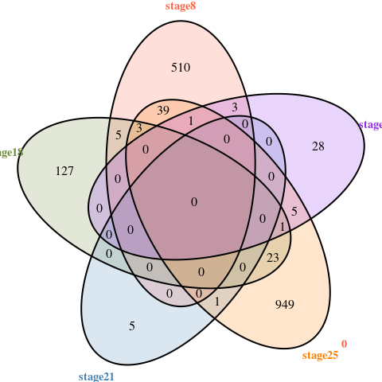

There is a large number of regions identified when only using the stage25 data, and most are not recovered with the average test, so it’ll be interesting to see what these regions are.

In terms of the stage comparisons, most of the differences on a per-somite basis are also significant when taking their average.

```r
ave <- GRanges(stage.average.all$seqnames, IRanges(stage.average.all$start, stage.average.all$end))
perSomite <- GRanges(stage.perSomite.all$seqnames, IRanges(stage.perSomite.all$start, stage.perSomite.all$end))

nDE <- matrix(c(length(perSomite), length(ave), length(unique(subjectHits(findOverlaps(ave, perSomite)))), length(unique(queryHits(findOverlaps(ave, perSomite))))), ncol=2)
colnames(nDE) <- c("total", "overlap")
row.names(nDE) <- c("perSomite", "average")
nDE
```

```
##           total overlap
## perSomite 17107   12876
## average   28404   13582
```

In terms of the per-somite results, somiteI data returns a much higher number of differences; 13,930 significant regions of which 75% are also recovered in the average analysis This suggests that the differences in numbers come from increased power (we have several replicates for all stages for somite I but not for the others) but also some of these regions might be significant in the average test driven by the somiteI behaviour.

For somites II and III, most of the regions are shared with the other somites, with about ~30% of their significant regions private.

```r
p <- makeVennDiagram(list(somiteI = stage.perSomite[["somiteI"]][stage.perSomite[["somiteI"]]$FDR<0.05,],
                          somiteII = stage.perSomite[["somiteII"]][stage.perSomite[["somiteII"]]$FDR<0.05,],
                          somiteIII = stage.perSomite[["somiteIII"]][stage.perSomite[["somiteIII"]]$FDR<0.05,]),
                     fill=c("tomato1", "darkolivegreen4", "steelblue"), alpha=0.2,
                     cat.col=c("tomato1", "darkolivegreen4", "steelblue"),
                     cat.fontface=2, cat.cex=0.9)
```

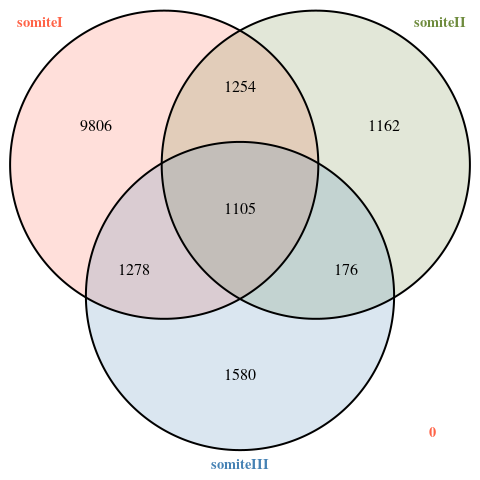

### Peak sets

For downstream analyses, we create independent sets of DA regions:

- **Robust set**: regions identified in average test plus at least one stage/somite-specific test.
- **Power set**: regions identified only in average test.
- **Specific set**: regions identified only in stage/somite-specific test; split by the comparison of relevance.

```r
## somite trios
trios.robust <- trios.average.all[intersect(row.names(trios.average.all), row.names(trios.perStage.all)),] # 383
trios.power <- trios.average.all[setdiff(row.names(trios.average.all), row.names(trios.robust)),] # 1,010
trios.specific <- trios.perStage.all[setdiff(row.names(trios.perStage.all), row.names(trios.robust)),] # 1,332
trios.specific.stage8 <- trios.specific[trios.specific$stage8.FDR < 0.05 &
                                          trios.specific$stage18.FDR > 0.05 &
                                          trios.specific$stage21.FDR > 0.05 &
                                          trios.specific$stage25.FDR > 0.05 &
                                          trios.specific$stage35.FDR > 0.05,] # 462
trios.specific.stage18 <- trios.specific[trios.specific$stage18.FDR < 0.05 &
                                          trios.specific$stage8.FDR > 0.05 &
                                           trios.specific$stage21.FDR > 0.05 &
                                          trios.specific$stage25.FDR > 0.05 &
                                           trios.specific$stage35.FDR > 0.05,] # 83
trios.specific.stage21 <- trios.specific[trios.specific$stage21.FDR < 0.05 &
                                          trios.specific$stage8.FDR > 0.05 &
                                           trios.specific$stage18.FDR > 0.05 &
                                          trios.specific$stage25.FDR > 0.05 &
                                           trios.specific$stage35.FDR > 0.05,] # 2
trios.specific.stage25 <- trios.specific[trios.specific$stage25.FDR < 0.05 &
                                          trios.specific$stage8.FDR > 0.05 &
                                           trios.specific$stage18.FDR > 0.05 &
                                          trios.specific$stage21.FDR > 0.05 &
                                           trios.specific$stage35.FDR > 0.05,] # 731
trios.specific.stage35 <- trios.specific[trios.specific$stage35.FDR < 0.05 &
                                          trios.specific$stage8.FDR > 0.05 &
                                           trios.specific$stage18.FDR > 0.05 &
                                          trios.specific$stage21.FDR > 0.05 &
                                           trios.specific$stage25.FDR > 0.05,] # 26
# 28 regions significant in two or more stages

## stage changes
stages.robust <- stage.average.all[intersect(row.names(stage.average.all), row.names(stage.perSomite.all)),] # 12,467
stages.power <- stage.average.all[setdiff(row.names(stage.average.all), row.names(stages.robust)),] # 15,937
stages.specific <- stage.perSomite.all[setdiff(row.names(stage.perSomite.all), row.names(stages.robust)),] # 4,640
stages.specific.somiteI <- stages.specific[stages.specific$somiteI.FDR < 0.05 &
                                             stages.specific$somiteII.FDR > 0.05 &
                                             stages.specific$somiteIII.FDR > 0.05,] # 3,974
stages.specific.somiteII <- stages.specific[stages.specific$somiteII.FDR < 0.05 &
                                              stages.specific$somiteI.FDR > 0.05 &
                                              stages.specific$somiteIII.FDR > 0.05,] # 300
stages.specific.somiteIII <- stages.specific[stages.specific$somiteIII.FDR < 0.05 &
                                               stages.specific$somiteI.FDR > 0.05 &
                                               stages.specific$somiteII.FDR > 0.05,] # 308
# 58 regions significant in two comparisons

save(trios.robust, trios.power, trios.specific, trios.specific.stage8, trios.specific.stage18, trios.specific.stage21, trios.specific.stage25, trios.specific.stage35, stages.robust, stages.power, stages.specific, stages.specific.somiteI, stages.specific.somiteII, stages.specific.somiteIII, file=paste0(dir, "ATAC-seq/results/04.5_DApeakSets.RData"))
```

### Genomic features of DA regions

Most open chromatin regions overlap or are near genes, but only about a fifth are in promoters. Thus, the vast majority of regions are putative regulatory elements. Also, DA regions are slightly enriched for more intergenic, compared to genic regions.

```r
peakCounts <- readRDS(paste0(dir, "ATAC-seq/results/04.4_peakCounts_csawMerged.Rds"))
peakSet <- rowRanges(peakCounts)
ann <- detailRanges(peakSet, TxDb.Mmusculus.UCSC.mm10.knownGene, org.Mm.eg.db, dist=5000, promoter = c(3000,300))
mcols(peakSet) <- ann

peakSet$DAtrios <- 0
peakSet$DAstages <- 0

tmp <- GRanges(trios.average.all$seqnames, IRanges(trios.average.all$start, trios.average.all$end))
tmp <- c(tmp, GRanges(trios.perStage.all$seqnames, IRanges(trios.perStage.all$start, trios.perStage.all$end)))
tmp <- unique(tmp)
peakSet[peakSet %in% tmp]$DAtrios <- 1

tmp <- GRanges(stage.average.all$seqnames, IRanges(stage.average.all$start, stage.average.all$end))
tmp <- c(tmp, GRanges(stage.perSomite.all$seqnames, IRanges(stage.perSomite.all$start, stage.perSomite.all$end)))
tmp <- unique(tmp)
peakSet[peakSet %in% tmp]$DAstages <- 1
saveRDS(peakSet, file=paste0(dir, "ATAC-seq/results/04.5_peakSet_csawMerged_geneAnn.Rds"))

# table(trios=peakSet$DAtrios, stages=peakSet$DAstages)
#      stages
# trios      0      1
#     0 139099  31077
#     1    758   1967

nDE <- matrix(c(
  length(peakSet[peakSet$overlap != ""])/length(peakSet)*100,
  length(peakSet[peakSet$overlap != "" & peakSet$DAtrios == 1])/length(peakSet[peakSet$DAtrios == 1])*100,
  length(peakSet[peakSet$overlap != "" & peakSet$DAstages == 1])/length(peakSet[peakSet$DAstages == 1])*100,

  length(peakSet[grep(":P", peakSet$overlap)])/length(peakSet)*100,
  length(peakSet[peakSet$DAtrios==1][grep(":P", peakSet[peakSet$DAtrios==1]$overlap)])/length(peakSet[peakSet$DAtrios==1])*100,
  length(peakSet[peakSet$DAstages==1][grep(":P", peakSet[peakSet$DAstages==1]$overlap)])/length(peakSet[peakSet$DAstages==1])*100,

  length(peakSet[peakSet$overlap=="" & (peakSet$left != "" | peakSet$right != "")])/length(peakSet)*100,
  length(peakSet[peakSet$DAtrios==1 & peakSet$overlap=="" & (peakSet$left != "" | peakSet$right != "")])/length(peakSet[peakSet$DAtrios == 1])*100,
  length(peakSet[peakSet$DAstages==1 & peakSet$overlap=="" & (peakSet$left != "" | peakSet$right != "")])/length(peakSet[peakSet$DAstages == 1])*100,

  length(peakSet[peakSet$overlap=="" & peakSet$left == "" & peakSet$right==""])/length(peakSet)*100,
  length(peakSet[peakSet$DAtrios==1 & peakSet$overlap=="" & peakSet$left == "" & peakSet$right==""])/length(peakSet[peakSet$DAtrios==1])*100,
  length(peakSet[peakSet$DAstages==1 & peakSet$overlap=="" & peakSet$left == "" & peakSet$right==""])/length(peakSet[peakSet$DAstages==1])*100
), ncol=3, byrow = TRUE)
colnames(nDE) <- c("all", "DAtrios", "DAstages")
row.names(nDE) <- c("overlapGenes", "inPromoter", "nearGenes", "intergenic")
round(nDE,2)
```

```
##                all DAtrios DAstages
## overlapGenes 63.66   52.55    59.63
## inPromoter   18.83    8.33    15.79
## nearGenes     5.89    4.92     4.49
## intergenic   30.46   42.53    35.89
```

```r
# table(unlist(lapply(strsplit(unlist(strsplit(peakSet[peakSet$overlap != ""]$overlap, ",")), ":"), "[[", 3)))
#     E     I     P    PE    PI
# 20219 65733 10413 24002  2422
```